# Titanic Data Analysis

Author

Bartosz Golubiewski

# 1 Introduction

The Titanic disaster is the world’s most famous shipwreck. Beyond it’s historical significance, the disaster provides an interesting case study for exploring patterns in passenger characteristics and survival outcomes. In this report, we use an expanded version of a well-known Titanic dataset, obtained from [Kaggle — Titanic Extended Dataset](https://www.kaggle.com/datasets/pavlofesenko/titanic-extended/data). It contains information about passengers aboard the RMS Titanic during it’s maiden voyage, including demographic variables, ticket and travel information, and survival status.

These variables provide an opportunity to examine how different passenger characteristics were associated with their chances of survival. The aim of this report is to explore the structure of the dataset and to identify the patterns that may help explain differences in survival outcomes.

The analysis begins with a general overview of the data, including its structure, variable types, and missing values, followed by the necessary data preparation. We then conduct an exploratory data analysis (EDA) to examine the distributions of individual variables and explore relationships between them.

To further investigate the structure of the data, Principal Component Analysis (PCA) and Multidimensional Scaling (MDS) are applied as dimensionality reduction techniques. These methods provide a lower-dimensional representation of the data while preserving its most important structure.

The next stage focuses on unsupervised learning. Two clustering methods are applied to the learning set to identify groups of passengers with similar characteristics and examine whether these groups are associated with different survival outcomes.

Finally, several supervised classification models are trained on the learning set and compared based on their predictive performance. The best-performing model is then evaluated on an unseen test set to assess its generalization ability and determine whether the patterns identified during training are maintained on new data.

# 2 Data Overview

The raw dataset consists of 1309 records and 21 variables, of which 10 are quantitative and 11 are categorical. Detailed information on the variables and their data types is provided in Table 1.

| Variable | Type | NAs |
| --- | --- | --- |
| PassengerId | integer | 0 |
| Survived | numeric | 418 |
| Pclass | integer | 0 |
| Name | character | 0 |
| Sex | character | 0 |
| Age | numeric | 263 |
| SibSp | integer | 0 |
| Parch | integer | 0 |
| Ticket | character | 0 |
| Fare | numeric | 1 |
| Cabin | character | 0 |

| Variable | Type | NAs |
| --- | --- | --- |
| Embarked | character | 0 |
| WikiId | numeric | 5 |
| Name_wiki | character | 0 |
| Age_wiki | numeric | 7 |
| Hometown | character | 0 |
| Boarded | character | 0 |
| Destination | character | 0 |
| Lifeboat | character | 0 |
| Body | character | 0 |
| Class | integer | 5 |

Table 1: Variables, their types, and number of missing records in raw dataset.

In total, the dataset contains 699 missing values. However, even a preliminary inspection of the data suggests that the actual extent of missing information is considerably greater, as some missing values are encoded in other forms (see Section 3.1).

# 3 Data Cleaning and Preparation

## 3.1 Missing Values and Irregular Entries

The first step of the data preparation process was to inspect the raw dataset for missing values, inconsistent data formats, and other potential issues that could affect subsequent analyses. The following key issues were identified and addressed:

- `Fare`: Zero values were treated as missing data rather than as valid fares. Although complimentary tickets did exist historically (e.g., for Bruce Ismay, his servants, and Thomas Andrews), treating zero fares as missing values was considered more appropriate for the purposes of this analysis.
- `Embarked` and `Boarded`: Empty strings were recoded as `NA` values.
- `Lifeboat`: Empty strings and question marks (`?`) were converted to `NA`. Additionally, irregular formatting in entries (e.g., `A[64]`) was cleaned to standard identifiers (e.g., `A`).

## 3.2 Missing Data Imputation

Missing values were imputed where possible using historical records, summary statistics, and contextual knowledge:

- `Embarked` and `Boarded`: These variables serve essentially identical purposes. Because missing values were not overlapping, missing entries in `Boarded` were imputed using corresponding values from `Embarked`.
- `Lifeboat`: A new category was introduced. For passengers who perished in the disaster, missing values in `Lifeboat` were transformed into `NS` (*No Survival*).
- `Survived`:
  - The extended dataset includes additional information about passengers based on the passenger list available on [Wikipedia](https://en.wikipedia.org/wiki/Passengers_of_the_Titanic#Passenger_list). Unfortunately, the dataset omits survival status, as this information is represented using color coding in the original Wikipedia table. This issue was addressed by scraping the Wikipedia table and merging the extracted survival information with the Kaggle dataset. As a result, the number of missing values in `Survived` has been significantly reduced.
  - In several instances, survival status was missing despite existing records in the `Lifeboat` variable. Historical records (e.g., [*Encyclopedia Titanica*](https://www.encyclopedia-titanica.org)) indicate that only a small number of known fatalities occurred among passengers who reached a lifeboat. Since no such cases were identified in this dataset, all passengers recorded as having occupied a lifeboat were assumed to have survived.
- `Age_wiki`: Missing values were imputed using the mean age within the passenger’s class of travel.
- `Fare`: Missing values were imputed using the mean fare within the passenger’s class of travel.

## 3.3 Data Preparation

After addressing the missing values, the dataset was further prepared for analysis. This included removing unnecessary information, standardizing variable names and data types. Following changes were made:

- Redundant columns (`Name_wiki`, `Name`, `Age`, `Class`, `Boarded`) were removed. When deciding between duplicate variables, preference was given to those with fewer missing records.
- Column names were standardized using `snake_case` notation, and some variables were renamed to improve readability (e.g., `SibSp` became `siblings_spouses`),
- Categorical variables, including `class`, `embarked`, `sex`, `lifeboat`, and `survived`, were converted to factors.
- Factor level and labels were standardized (e.g., binary indicators `0` and `1` in `survived` were relabeled as `No` and `Yes`).

## 3.4 Data Transformation

Additional features were created from the existing variables to capture information that may be useful for the subsequent analysis:

- `family_size`: Defined as `siblings_spouses + parents_children + 1`.
- `family_size_group`: A factor with 4 distinct levels:
  - `alone`: if `family_size` $= 1$
  - `small`: if $2 \le$ `family_size` $\le 4$
  - `medium`: if $5 \le$ `family_size` $\le 7$
  - `large`: if `family_size` $> 7$
- `is_child`: A factor classifying age brackets:
  - `child`: if `age` $< 15$ (reflecting the historical context of the Titanic, where teenagers were treated as adults)
  - `adult`: if `age` $\ge 15$
- `age_group`: A factor segmenting life stages into 4 categories:
  - `child`: if `age` $< 15$
  - `young adult`: if $15 \le$ `age` $< 30$
  - `adult`: if $30 \le$ `age` $< 60$
  - `senior`: if `age` $\ge 60$

Following this process, the now cleaned dataset contains 13 variables — 5 quantitative and 8 qualitative. The number of missing values is 43. Detailed information is provided in Table 2.

| Variable | NAs | Type | Levels |
| --- | --- | --- | --- |
| survived | 15 | factor | No, Yes |
| class | 0 | factor | 1st, 2nd, 3rd |
| sex | 0 | factor | female, male |
| siblings_spouses | 0 | integer |  |
| parents_children | 0 | integer |  |
| fare | 0 | numeric |  |
| embarked | 0 | factor | C, Q, S |
| age | 0 | numeric |  |
| lifeboat | 28 | factor | 1, 2, 3, 4, 5, 6, 7, 8, 9, 10, 11, 12, 13, 14, 15, 16, A, B, C, D, NS |
| family_size | 0 | numeric |  |
| family_size_group | 0 | factor | alone, small, medium, large |
| is_child | 0 | factor | adult, child |
| age_group | 0 | factor | child, young adult, adult, senior |

Table 2: Variables, their types, and number of missing records in dataset after data cleaning.

# 4 Exploratory Data Analysis

Exploratory Data Analysis (EDA) is an essential step in understanding the patterns and key characteristics of the dataset. In this section we examine the data using summary statistics and visualizations to identify relationships between variables.

## 4.1 Distributions of Quantitative Variables

Here, we take a closer look at the distributions of the quantitative variables (`siblings_spouses, parents_children, fare, age, family_size`) in the dataset. This helps us understand how the values are spread out and spot any noticeable patterns or outliers.

| Variable | Min | Max | SD | Mean | Median | Q1 | Q3 |
| --- | --- | --- | --- | --- | --- | --- | --- |
| age | 0.17 | 74.00 | 13.73 | 29.42 | 28.0 | 21.00 | 38.00 |
| family_size | 1.00 | 11.00 | 1.58 | 1.88 | 1.0 | 1.00 | 2.00 |
| fare | 3.17 | 512.33 | 51.78 | 33.90 | 14.5 | 7.92 | 31.39 |
| parents_children | 0.00 | 9.00 | 0.87 | 0.39 | 0.0 | 0.00 | 0.00 |
| siblings_spouses | 0.00 | 8.00 | 1.04 | 0.50 | 0.0 | 0.00 | 1.00 |

Table 3: Summary measures of quantitative variables.

Summary statistics for the quantitative variables can be found in Table 3. Missing values were removed separately for each variables when calculating the statistics. It is worth noting the large differences in the ranges of some variables’ values, which may indicate a need for standarization when using distance-sensitive algorithms (Section 7).

The same conclusion can be drawn from the analysis of boxplots shown in Figure 1. Furthermore, a number of outliers can be observed for each variable. They are represented by individual points and correspond to values outside the range of $Q_1 - 1.5\cdot(Q_3 - Q_1)$ and $Q_3 + 1.5\cdot(Q_3 - Q_1)$.

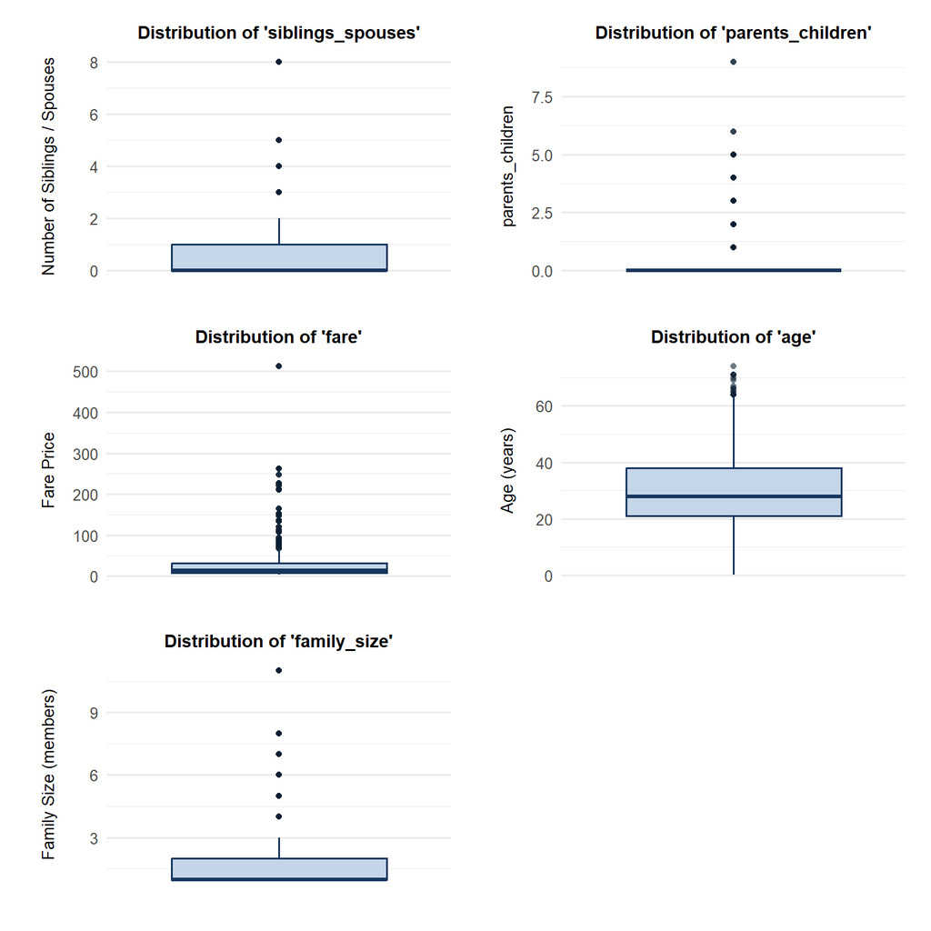

Figure 1: Distributions (boxplots) of quantitative variables.

The kernel density estimates of quantitative variables, shown in Figure 2, reveal that all of the variables exhibit noticeable positive skewness, with most observations concentrated toward the lower end of their respective ranges. Although `age` also shows a slight positive skew, it’s distribution is considerably closer to symmetry than those of the other variables.

It should also be noted that density plots of the discrete variables (`siblings_spouses`, `parents_children`, and `family_size`) have a jagged, spiky appearance due to their integer-valued nature.

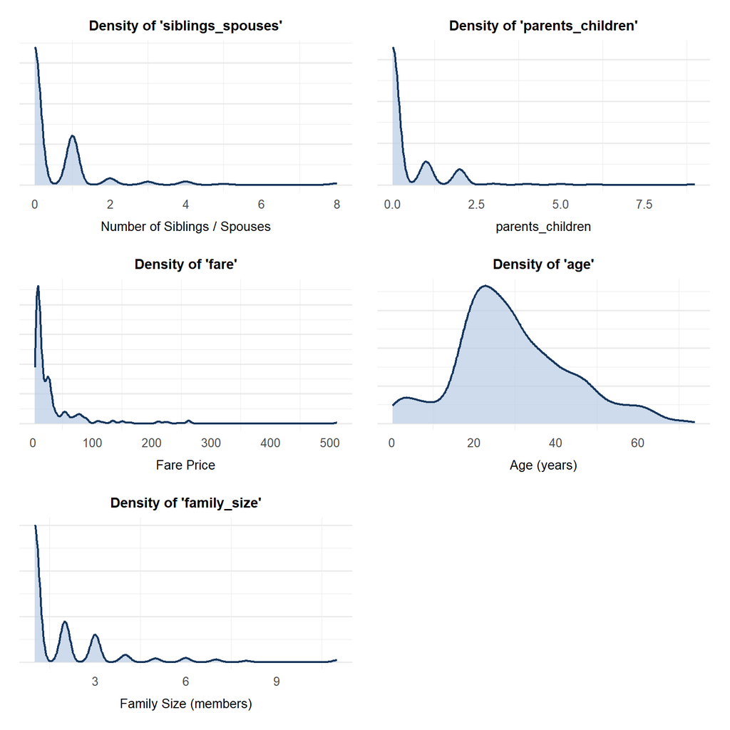

Figure 2: Kernel density estimates of quantatitive variables.

## 4.2 Distributions of Qualitative Variables

Here, we take a closer look at the distributions of the qualitative variables (`survived, class, sex, embarked, lifeboat, family_size_group, is_child, age_group`) in the dataset. The distributions are visualized in Figure 3. Missing values were excluded from the analysis.

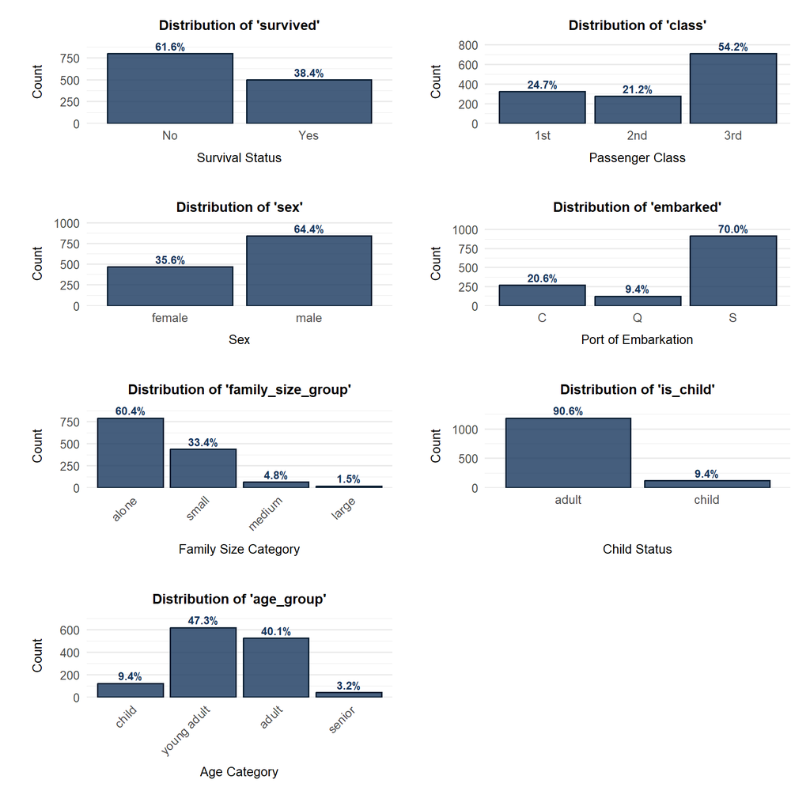

Figure 3: Distributions (barplots) of qualitative variables.

Non-survivors constitute majority of passengers, with a fatality rate of $61,6\%$. This is consistent with the distribution of `lifeboat` (Table 4) — when the corresponding lifeboat categories are combined, the proportion of passengers who did not board a lifeboat is broadly consistent with the proportion of non-survivors. The small discrepancy can be attributed primarily to missing values.

Males account for nearly two-thirds of the passengers. The age distribution is concentrated in `young adult` and `adult` groups, which together account for almost $90\%$ of all passengers. More than half of the passengers traveled in 3rd-class, making it more numerous than 1st- and 2nd-class combined. Most passengers traveled without relatives, accounting for approximately $60\%$ of all observations. Although `small` family groups represent $33\%$ of observations, larger families are rare.

The distribution of departure locations is heavily imbalanced, with Southampton (`S`) accounting for $70.0\%$ of passengers, followed by Cherbourg (`C`) with $20.6\%$ and Queenstown (`Q`) with $9.4\%$.

| Lifeboat | Count | % |
| --- | --- | --- |
| 1 | 5 | 0.4% |
| 2 | 14 | 1.1% |
| 3 | 26 | 2% |
| 4 | 31 | 2.4% |
| 5 | 29 | 2.3% |
| 6 | 21 | 1.6% |
| 7 | 22 | 1.7% |
| 8 | 24 | 1.9% |
| 9 | 26 | 2% |
| 10 | 29 | 2.3% |
| 11 | 26 | 2% |

| Lifeboat | Count | % |
| --- | --- | --- |
| 12 | 18 | 1.4% |
| 13 | 42 | 3.3% |
| 14 | 35 | 2.7% |
| 15 | 39 | 3% |
| 16 | 23 | 1.8% |
| A | 12 | 0.9% |
| B | 9 | 0.7% |
| C | 41 | 3.2% |
| D | 18 | 1.4% |
| NS | 791 | 61.7% |

Table 4: Distribution of `lifeboat`.

## 4.3 Correlation Matrix

To further investigate the relationships between variables, we examine their pairwise correlations. This allows us to assess the strength and directions of the associations between variables and identify any particularly strong relationships.

The correlation matrices for the quantitative variables are shown in Figure 4. Two different correlation measures were used: Spearman’s rank correlation (Figure 4 (a)) and Pearson’s correlation (Figure 4 (b)).

Pearson’s correlation measures the strength of linear relationships between variables and can be sensitive to outliers and departures from normality. In contrast, Spearman’s correlation is based on the ranks of the observations rather than their raw values. As a result, it is less sensitive to outliers and is suitable for detecting relationships that may not be strictly linear.

Both measures range from $-1$ to $1$, where negative values indicate an inverse association and positive values indicate a direct association. Values $> |0.7|$ can be interpreted as indicating strong associations.

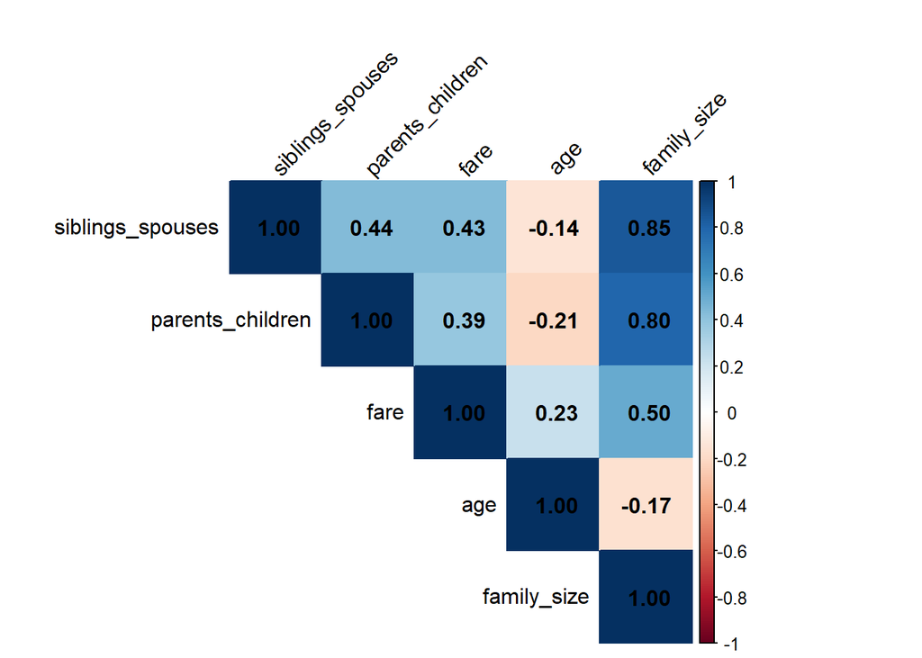

(a) Spearman

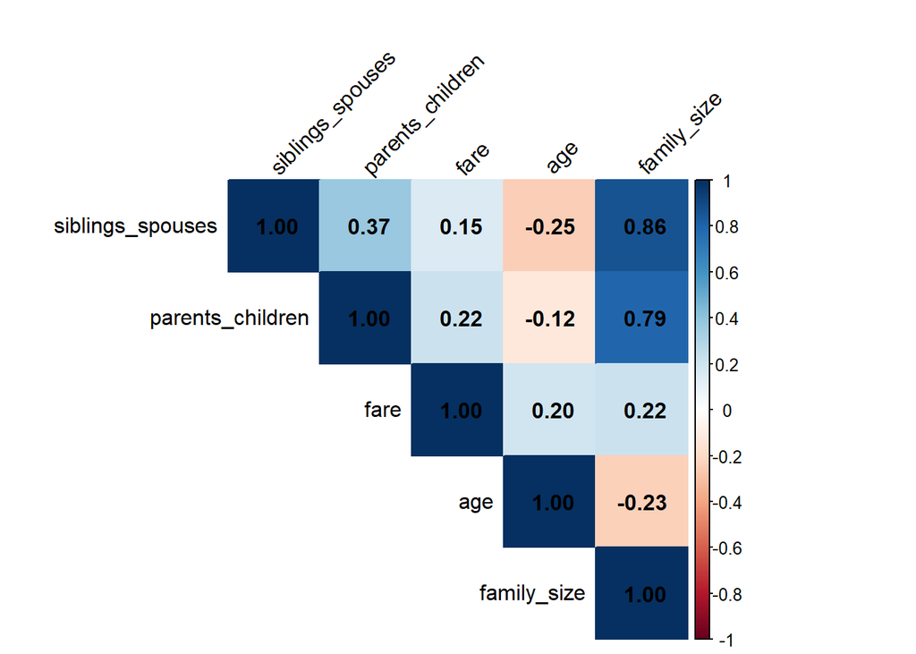

(b) Pearson

Figure 4: Correlation matrixes for quantitative variables

In this dataset, Pearson’s correlation generally produces weaker correlation coefficients than Spearman’s, particularly for pairs involving `fare`. As shown in Figure 2 and Figure 1, fare is strongly positively skewed and contains several high-value outliers. Under these conditions, Spearman’s correlation is less affected by extreme observations and therefore provides a more robust measure of the strength of the associations.

A strong correlation can also be observed between `family_size` and its components, with coefficients of $0.85$ for `siblings_spouses` and $0.80$ for `parents_children`. This relationship is expected, as both variables directly contribute to the overall `family_size`. To avoid redundant features in later predictive models, we can keep `family_size` and remove `siblings_spouses` and `parents_children`.

To examine relationships among categorical variables, we calculate a *Cramer’s V association matrix* (Figure 5). *Cramer’s V* measures the strength of association between categorical variables based on the $\chi^2$ statistic. Unlike previous correlation coefficients, *Cramer’s V* is non-directional. Its values range from $0$, indicating no association, to $1$, indicating a perfect association.

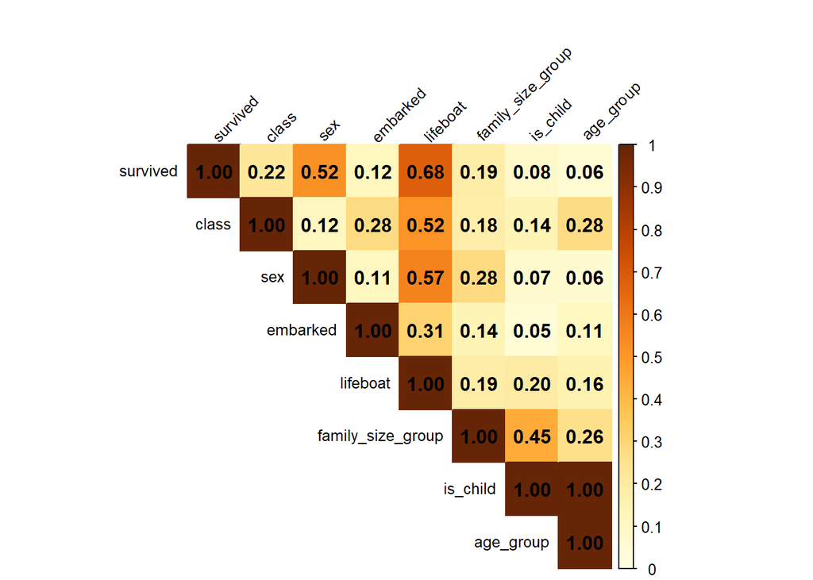

Figure 5: Cramer’s V Association Matrix (Qualitative Variables).

Furthermore, strong associations between `lifeboat` and `sex` ($0.57$) and between `lifeboat` and `class` ($0.52$) can be observed. The perfect association between `is_child` and `age_group` ($1.00$) is expected, as `is_child` was derived directly from `age_group` — one of these features should be omitted in predictive models.

## 4.4 Qualitative Variables vs Survival

To further examine the associations between qualitative features and the target variable (`survived`), proportion plots were constructed (Figure 6).

The strong *Cramer’s V association* previously observed for `sex` (Figure 5) is clearly justified by these distributions, as the difference in survival rate between sexes is staggering ($72.8\%$ for women vs. $19.3\%$ for men). Conversely, while the overall association coefficient between `class` and `survived` was moderate, the plot reveals clear differences in survival across classes. Passengers in 1st-class achieving a survival rate of $62.6\%$, nearly two and a half times higher than those in 3rd-class ($25.4\%$), with 2nd-class occupying a middle position ($43.8\%$).

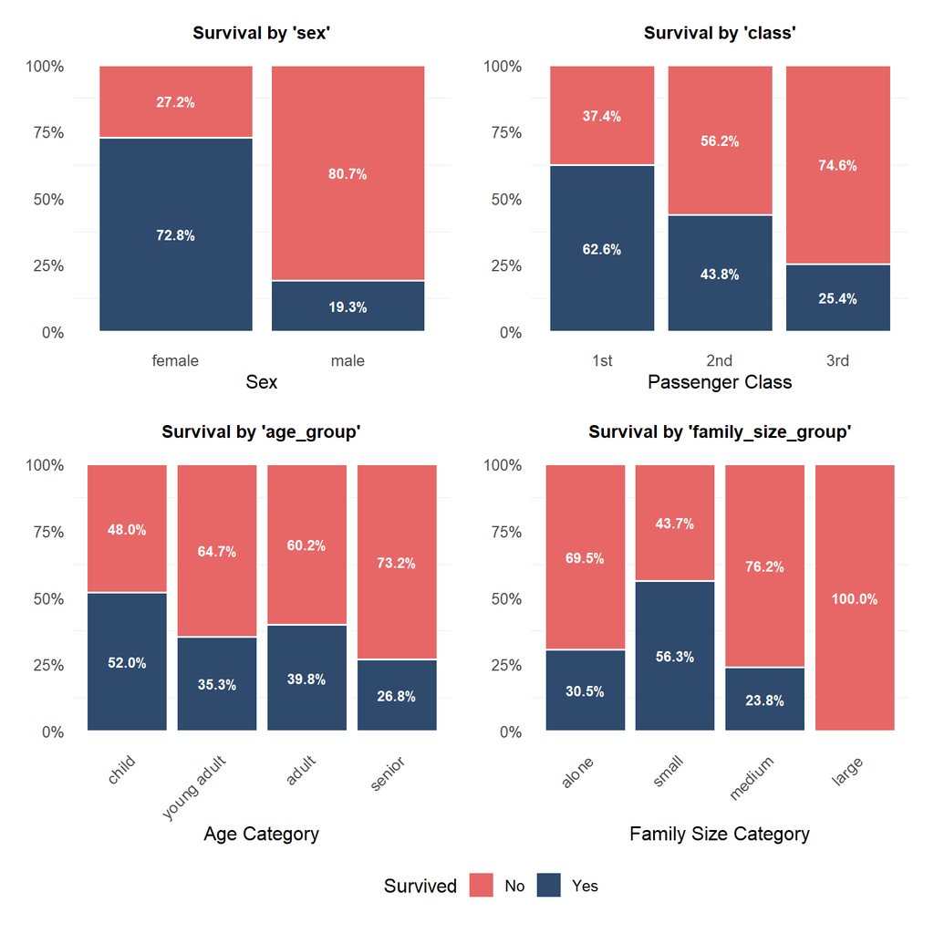

Figure 6: Survival rates by selected qualitative variables.

Regarding age categories, children exhibited the highest survival rate ($52.0\%$). The survival rates for young adults ($35.3\%$) and adults ($39.8\%$) were substantially lower and relatively comparable. Although seniors recorded the lowest survival rate ($26.8\%$), this result should be interpreted with caution due to the small sample size of this subgroup (as shown in Figure 3).

A similar caveat applies to family size categories — while medium ($23.8\%$) and large ($0.0\%$) families display notably lower survival rates, they represent a small minority of observations. Of greater significance is the contrast between solo travellers (`alone`) and small families — individuals traveling in small family units were nearly twice as likely to survive ($56.3\%$) compared to those traveling alone ($30.5\%$).

## 4.5 Quantitative Variables vs Survival

To examine how continuous variables relate to survival status, kernel density estimates were constructed (Figure 7).

The continuous distribution of `age` aligns closely with the earlier categorical findings. The survival density (blue) visibly exceeds non-survival (red) for young children under 10 years old. Between ages 20 and 30, non-survival dominates slightly, after which the two curves broadly overlap across middle and older age brackets. Similarly, the continuous variant of `family_size_group` does not provide any new information, as passengers traveling alone had a higher fatality rate, while those traveling in smaller families (2–4 people) had a higher chance of survival.

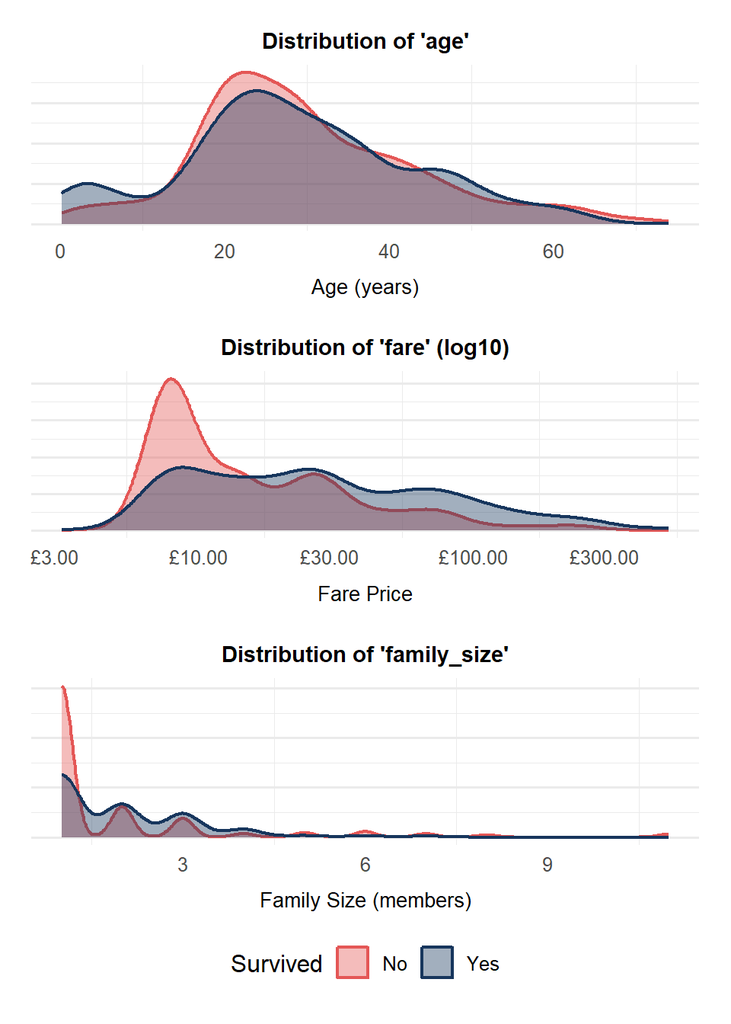

Figure 7: Survival rates by selected quantitative variables.

The differences are considerably more pronounced for `fare` (displayed on a $\log_{10}$ scale to handle skewness). The lower end of fare spectrum is dominated by non-survivors, producing a sharp red peak. Beyond $£30$, and particularly $£100$, the density shifts in favour of survivors. This further confirms that better class of travel increased the likelihood of survival.

## 4.6 Multivariate Analysis

In this sections, we combine the previously examined variables to gain a more comprehensive understanding of the factors associated with survival. By considering multiple variables simultaneously, we can identify patterns and relationships that may not be apparent from the individual analyses and use them as a basis for the final conclusions.

Figures in Figure 8 and Figure 9 examine how socio-demographic and economic factors jointly relate to passenger survival.

- Sex remains the strongest factor associated with survival, but the size of the difference between females and males varied considerably by passenger class. Adult women in 1st- and 2nd-class had very high survival rates, reaching $97.7\%–97.8\%$ in 1st-class and $87.2\%–88.1\%$ in 2nd-class for young adults and adults, respectively. Senior women in 1st-class also maintained high survival ($87.5\%$).

  In contrast, men experienced high mortality across all classes: 2nd-class adult male survival fell to $6.7\%$ ($11.0\%$ for young adults), while 1st-class senior male survival dropped to just $6.2\%$.
- The role of age varied considerably by passenger class. Male children in 1st and 2nd class had survival rates of $100.0\%$ and $91.7\%$, respectively, while 2nd-class female children reached a rate of $100.0\%$. The $50\%$ survival among 1st-class female children should be interpreted cautiously, as it’s likely affected by the small number of observations.

  In 3rd-class, however, child survival was substantially lower, at $39.0\%$ for females and $33.3\%$ for males. This suggests that the survival advantage observed among children in the higher classes was not present to the same extend among those travelling in 3rd-class.
- 3rd-class passengers consistently had lower survival rates. Even among adult women, survival in 3rd-class was considerably lower, at $36.2\%$ for adults and $57.7\%$ for young adults. Survival among adult men in 3rd-class remained low at $12.8\%-13.6\%$, while no 3rd-class male seniors in the dataset survived. The latter result should again be interpreted with caution due to the small sample size.

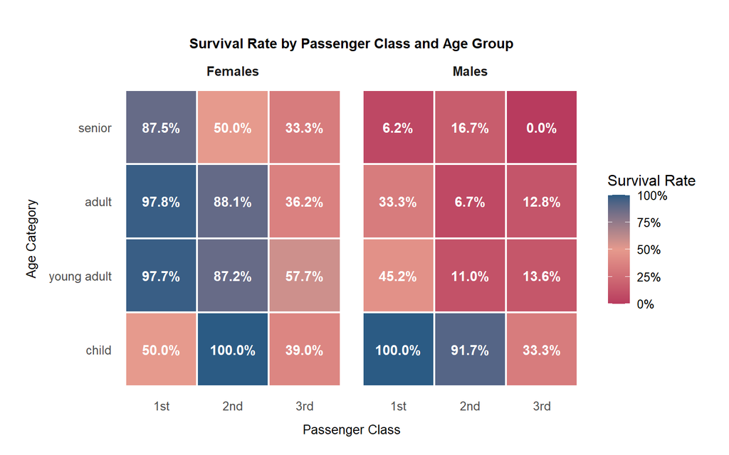

(a) Survival rates across passenger classes and age groups, faceted by sex.

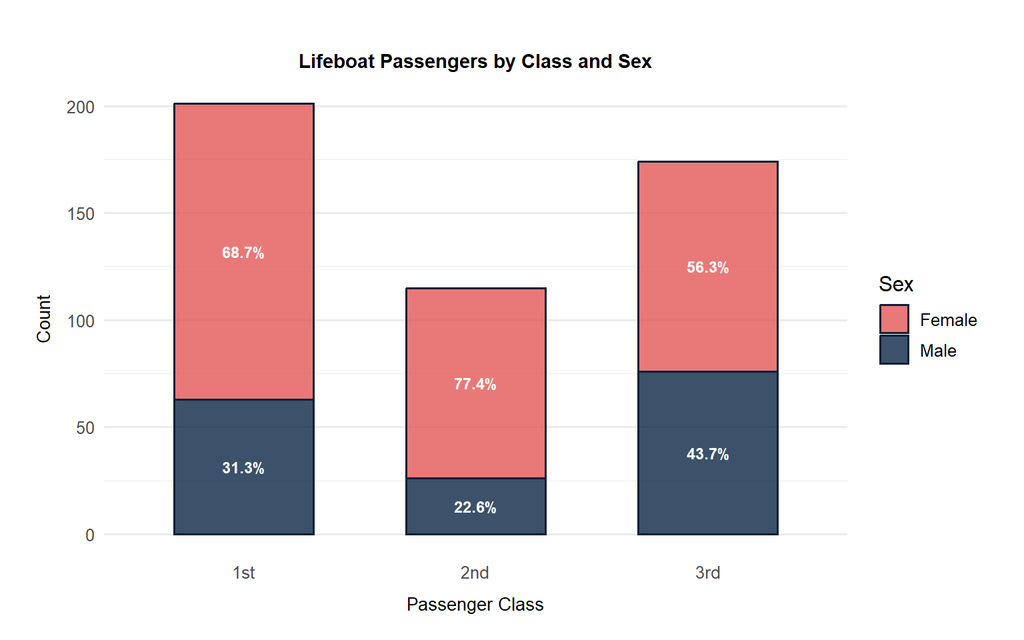

(b) Lifeboat passengers by class and sex, with percentages showing the sex composition within each class.

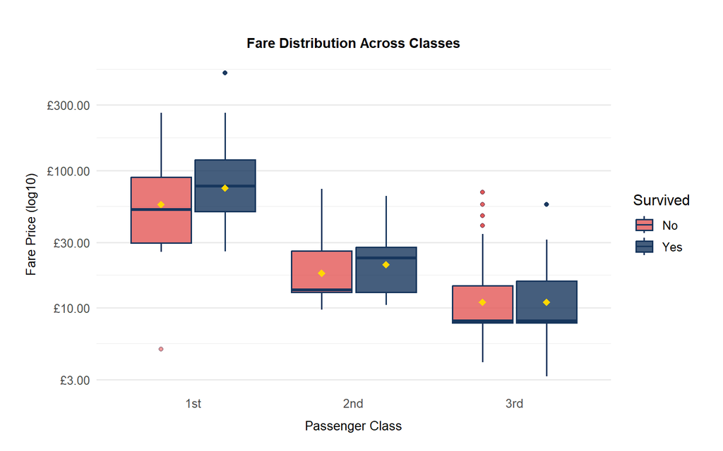

(c) Boxplot of ticket fare (log10 scale) by class and survival status. The horizontal line represents the median, while the yellow diamond indicates the mean.

Figure 8: Socio-demographic and economic factors associated with passenger survival.

The bar plot in Figure 8 (b) examines the sex and class composition of passengers who boarded the lifeboats (and, as established in Section 4.2, survived).

- 1st-class passengers accounted for the largest absolute number of lifeboat occupants, with more that 200 people. This becomes particularly notable when compared with the overall class distribution (see Figure 3): 1st-class passengers represented only $24.7\%$ of the total populations, compared with $54.2\%$ for 3rd-class. Among lifeboat occupants, however, 1st-class passengers accounted for $41\%$:

  $$\frac{\text{1st-class lifeboat occupants}}{\text{all lifeboat occupants}} \approx 41.02 \% \qquad \qquad \frac{\text{1st-class passengers}}{\text{all passengers}} \approx 24.68 \%$$

  This indicates a substantial overrepresentation of 1st-class passengers among those who reached the lifeboats. The pattern is consistent with historical layout of the ship, where 1st-class accommodation was generally located closer to the boat deck, reducing the distance passengers had to travel to reach the lifeboat stations.
- Women were strongly overrepresented among lifeboat occupants in 1st- and 2nd-class. They accounted for $68.7\%$ of 1st-class and $77.4\%$ of 2nd-class lifeboat occupants. This pattern is consistent with the historical application of *Birkenhead drill* (*women and children first*). The particularly high female representation in the upper classes may also reflect their easier access to the boat deck and the more orderly evacuation during the early stages of the sinking. Importantly, the Titanic did not begin with a single, clearly announced general evacuation, as the crew initially sought to avoid unnecessary panic. This meant that passengers depended heavily on information provided by crew members and on their ability to reach the boat deck.
- The gender gap was considerably smaller among 3rd-class lifeboat occupants. In 3rd-class, women accounted for $56.3\%$ of lifeboat occupants, compared with $43.7\%$ men. This relatively small difference should be interpreted in the context of the gender composition of 3rd-class, which was more male-dominated ($69.53\%$ male).

  This result should also be considered in it’s historical context. A common popular depiction of the Titanic disaster is that 3rd-class passengers were deliberately locked below deck and systematically prevented from reaching the lifeboats. This is, however, a myth rather than an accurate description of the evacuation. There was no simple, ship-wide policy of locking 3rd-class passengers below deck to prevent them from reaching the lifeboats. Their access was nevertheless more difficult in practice due to the ship’s layout, their greater distance from the boat deck, unfamiliarity with the vessel, language barriers, and their reliance on crew members for directions. The experience of 3rd-class steward [John Edward Hart](https://www.encyclopedia-titanica.org/titanic-survivor/john-edward-hart.html), who helped guide passengers from the lower decks towards the boat deck during the evacuation, illustrates the important role that crew members played in helping 3rd-class passengers navigate the ship.

- A clear price gap separates the three passenger classes, with 1st-class fares consistently exceeding those of the other two classes. While 1st-class fares ranged from approximately $£30$ to over $£100$, 2nd-class passengers generally paid between $£15$ and $£30$, whereas 3rd-class fares were concentrated between $£7$ and $£17$.
- Among 1st-class passengers, higher fares were associated with a clear survival advantage. Both the median fare and the mean fare, indicated by the yellow diamond, were noticeably higher among survivors than non-survivors.
- A slight positive shift in the mean fare can also be observed among 2nd-class survivors, although the difference is less pronounced. In 3rd-class, however, this effect largely disappears. The distributions, medians, and mean fares of survivors and non-survivors are nearly identical, suggesting that paying a slightly higher fare within 3rd-class did not provide a meaningful survival advantage.

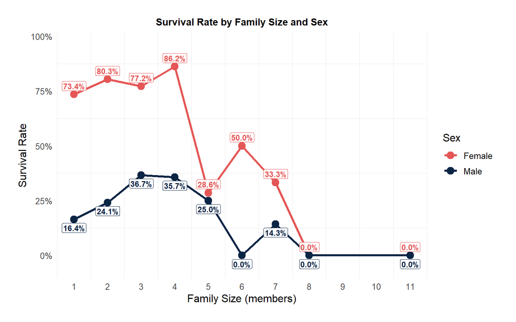

(a) Survival rates across family sizes for female and male passengers.

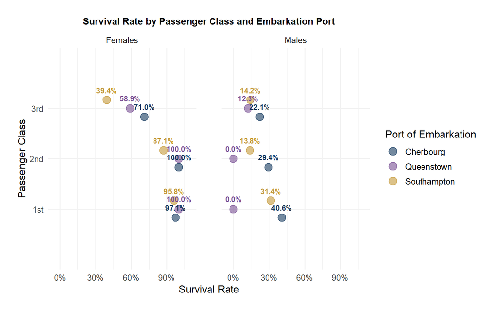

(b) Survival rates across passenger classes and embarkation ports, faceted by sex.

Figure 9: Impact of family structure and embarkation port on survival.

The figure in Figure 9 (a) shows how family size and sex influenced survival rates.

- A similar pattern can be observed for both sexes: survival rates increased with family size, reaching their highest levels for families of $3$–$4$ members, before dropping sharply for larger families. However, it should be noted that the sample sizes for medium and large families ($>5$ members) are relatively small (Figure 3). Consequently, the fluctuations observed for larger families should be interpreted with caution.
- When compared with the baseline average survival rates by sex (Figure 6), travelling with family was associated with a higher probability of survival. Among female passengers, the overall survival rate was $72.8\%$, compared with $73.4\%$ among those travelling alone and up to $86.2\%$ among those travelling in small families. For male passengers, the corresponding rates were $19.3\%$ overall, $16.4\%$ for those travelling alone, and up to $36.7\%$ for those travelling in small families.

  The positive association between family travel and survival was particularly pronounced among male passengers, for whom travelling in a small family was associated with a notably higher survival rate than travelling alone.

The plot in Figure 9 (b) illustrates the relationship between embarkation port, passenger class, sex, and survival.

## 4.7 EDA Summary

The exploratory data analysis revealed several key patterns in passenger survival. Survival was strongly associated with sex and passenger class, which emerged as the most influential factors. Other features, such as fare, age, and family size, showed additional and often non-linear relationships with survival. In particular, smaller families ($2$–$4$ members) and younger age groups were associated with higher survival rates, although these effects varied across demographic groups.

The analysis also highlighted critical technical considerations for subsequent dimensionality reduction via PCA and MDS. The numerical variables differ considerably in scale, with `fare` having a particularly wide range and some extreme values. Several numerical variables are also noticeably skewed. These differences make standardization and, where appropriate, feature transformations important, particularly for methods that are sensitive to scale. Outliers and small subgroup sizes should also be considered when interpreting the results.

# 5 Principal Component Analysis

*Principal Component Analysis* (PCA) is a linear dimensionality reduction method, that transforms a set of potentially correlated variables into a smaller set of linearly uncorrelated principal components, preserving as much variance as possible.

For this analysis, the continuous variables were selected (`fare`, `age`, `siblings_spouses`, `parents_children`). The `class` variable, although originally categorical, was also included by treating it as an ordinal variable and mapping its labels to their corresponding numerical values. This approach was considered appropriate because passenger class has a natural ordering, with the numerical values representing the relative position of each class. Furthermore, as shown in Section 4, passenger class was identified as one of the most important factors associated with survival.

Because PCA is highly sensitive to variable scales, and features like `fare` exhibit great value dispersion (see Figure 1), all variables were standardized prior to the analysis.

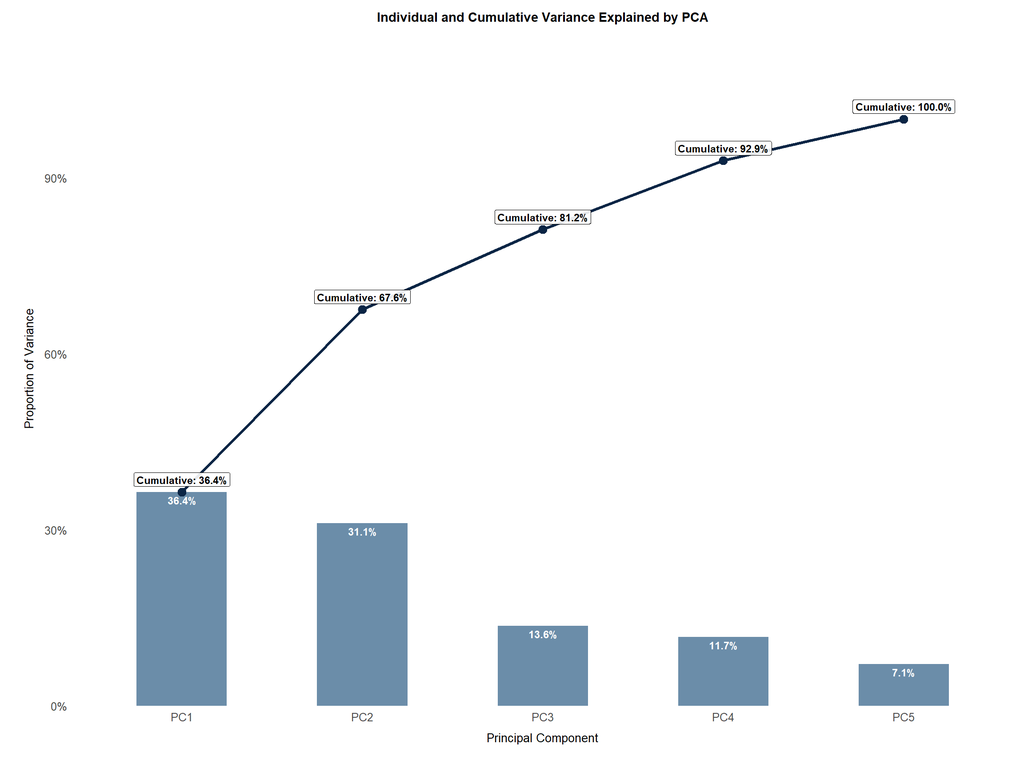

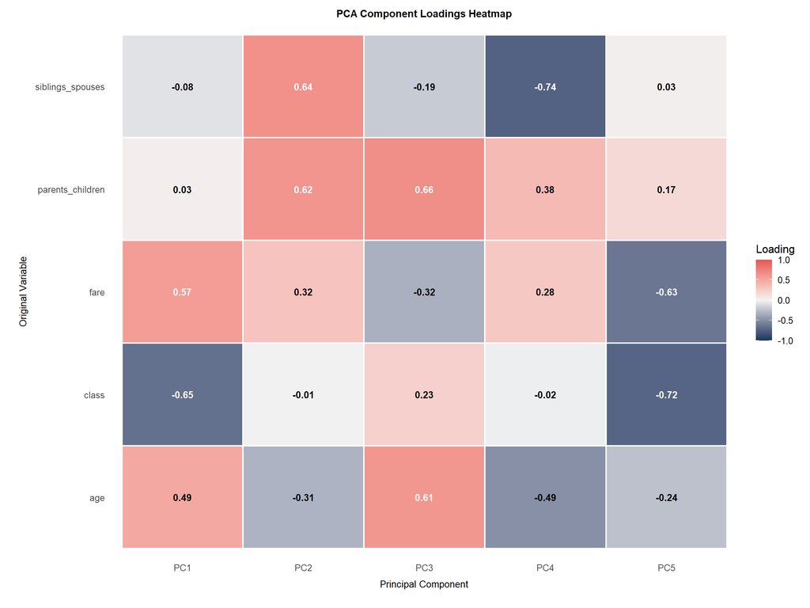

(b) Heatmap of variable contributions to the principal components.

Figure 10: Scree plot and feature loadings from the Principal Component Analysis.

The scree plot (Figure 10 (a)) shows that the first three principal components account for approximately $80\%$ of the total variance. As detailed in Figure 10 (b), the loadings matrix reveals how each original feature contributes to these new dimensions, with absolute values closer to 1 indicating a stronger relationship.

Primarily associated with `fare` and `class`, `PC1` effectively captures passenger wealth and accommodation (with a contribution from `age`). `PC2` is dominated by variables describing family structure (`siblings_spouses` and `parents_children`), isolating family group size from economic status.

Although three components are required to capture $80\%$ of the variance, using the first two components (`PC1`, `PC2`) allows us to visually inspect how socio-economic status and family size separate survivors from non-survivors.

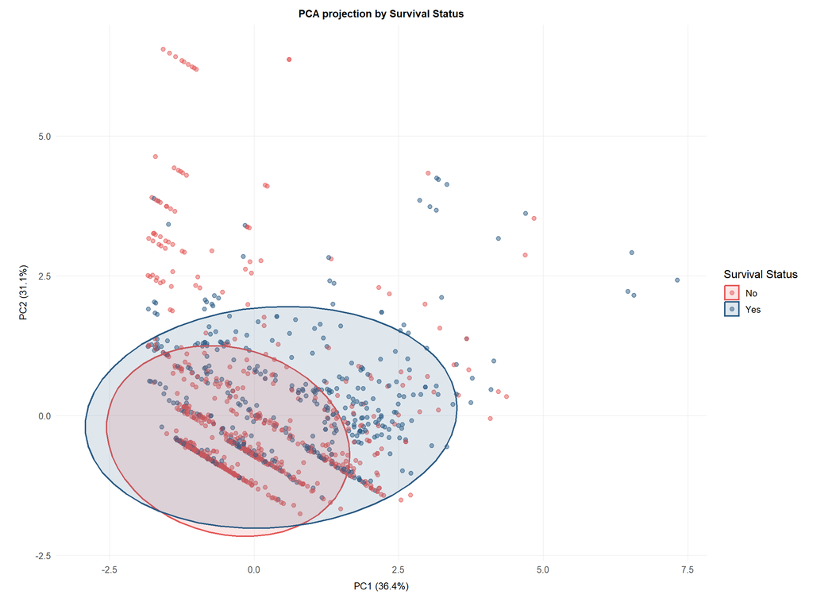

(a) 2D scatter plot of passengers with 95% confidence ellipses by survival.

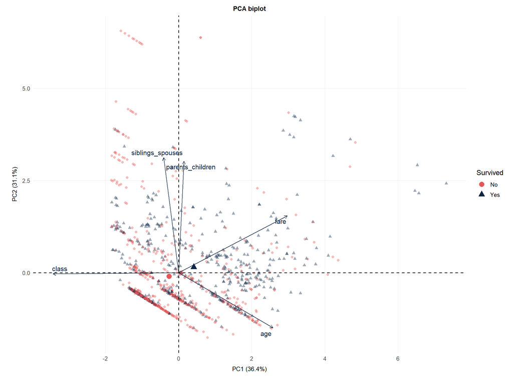

(b) PCA biplot showing passengers groups with original variable vectors.

Figure 11: Passenger distribution in the PC1-PC2 space by survival.

To assess the accuracy of the PCA procedure, plots were generated (Figure 11) with observations coloured according to the `survived` variable. Importantly, this variable was not included in the PCA calculations and was only used for visual interpretation.

The scatter plot with $95\%$ confidence ellipses (Figure 11 (a)) illustrates the degree of separation between survivors and non-survivors in the spaced defined by the first two principal components, while Figure 11 (b) presents a biplot showing the original variable vectors in the PCA space.

- A noticeable rightward shift can be observed for the surviving group. Since positive values of `PC1` are associated with age, higher ticket fares, and higher passenger class (i.e., lower numerical values of `class`, as indicated by the direction of the `class` vector), this shift suggests that socio-economic status contributes to the separation of survivors along the first principal component. This is consistent with the findings of the earlier exploratory data analysis.
- Both groups show a similar spread along the `PC2` axis, with their ellipse centres being relatively close vertically. This suggests that family size does not clearly distinguish survivors from non-survivors using through a linear relationship along the second principal component. This is consistent with the EDA results (see Figure 9 (a)), which indicate that the relationship between family size and survival is not linear.

The considerable overlap between the two $95\%$ confidence ellipses indicates that the first two principal components do not provide a clear linear separation between the two groups. Thus, while $PC_1$ captures some variation associated with survival, the substantial overlap suggests that the continuous variables represented in the PCA space are insufficient to fully distinguish survivors from non-survivors. This motivates further analysis using methods such as MDS and non-linear classification models.

# 6 Multidimensional Scaling

## 6.1 Method and Assesment of Accuracy

*Multidimensional Scaling* (MDS) is a dimensionality reduction technique that aims to measure the distance between variables and represent them in a lower-dimensional space while preserving their pairwise dissimilarities as accurately as possible.

Not all variables were included in the MDS procedure. The analysis was conducted without `family_size`, as it duplicates data of `parents_children` and `siblings_spouses`, `is_child`, as it duplicates information contained in `age`, and `lifeboat`, as it directly determines survival. The following variables were also excluded from the calculations but were used in selected plots in this section: `survived`, `age_group`, `family_size_group`. The categorical versions of quantitative variables were used to facilitate plots analysis.

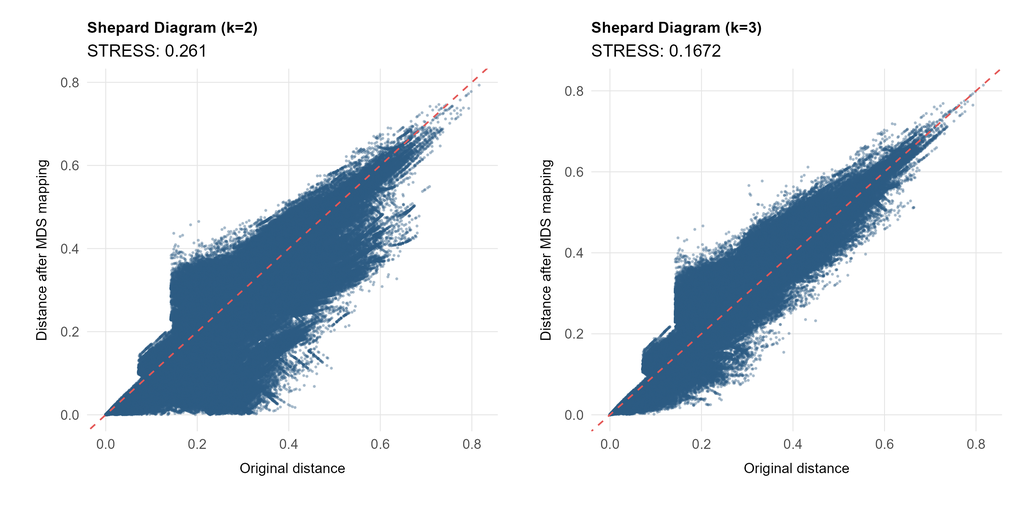

Figure 12: Shepard diagrams for different values of the target dimensionality $k$ in multidimensional scaling. The red line represents the ideal $y=x$ fit.

In this analysis, Gower’s distance was used to calculate dissimilarities between observations, as it is suitable for datasets containing mixed types of variables, including numerical and categorical variables. The resulting dissimilarity matrix was then used to perform MDS and represent the observations in two- and three-dimensional spaces. Observations that are closer together in the MDS space are more similar with respect to the analyzed characteristics, whereas larger distances indicate greater dissimilarity.

The quality of the fit was assessed using the STRESS measure, which defines the degree of “distortion” of distances after the MDS procedure:

$$STRESS = \sqrt{\cfrac{\sum(d_{ij} - \hat d_{ij})^2}{\sum d_{ij}^2}}$$
Where:

- $d_{ij}$ — the original distances calculated using the `daisy()` function,
- $\hat d_{ij}$ — the Euclidean distances in the reduced-dimensional space.

The *STRESS* value ranges from 0 to 1, with lower values indicating a better representation of the data structure.

Solutions with two and three dimensions was compared. A visual assessment of the fit is provided by Shepard diagrams (Figure 12), which show the relationship between the original distances and their mapped counterparts. The closer the points are to the diagonal line ($y=x$), the better the structure of the data has been preserved. Based on the *STRESS* values and the distribution of points in the plots, it can be concluded that reducing the data to three dimensions provides a better representation than reducing it to two dimensions.

## 6.2 MDS Visualization by Survival

Figure 13 presents the results of multidimensional scaling to two- and three-dimensional spaces. In both cases, distinct groups of observations can be identified. When the points are coloured according to survival status, these groups appear to be separated to some extent by survival. The following discussion focuses on the two-dimensional representation, as it is less accurate but easier to interpret and describe.

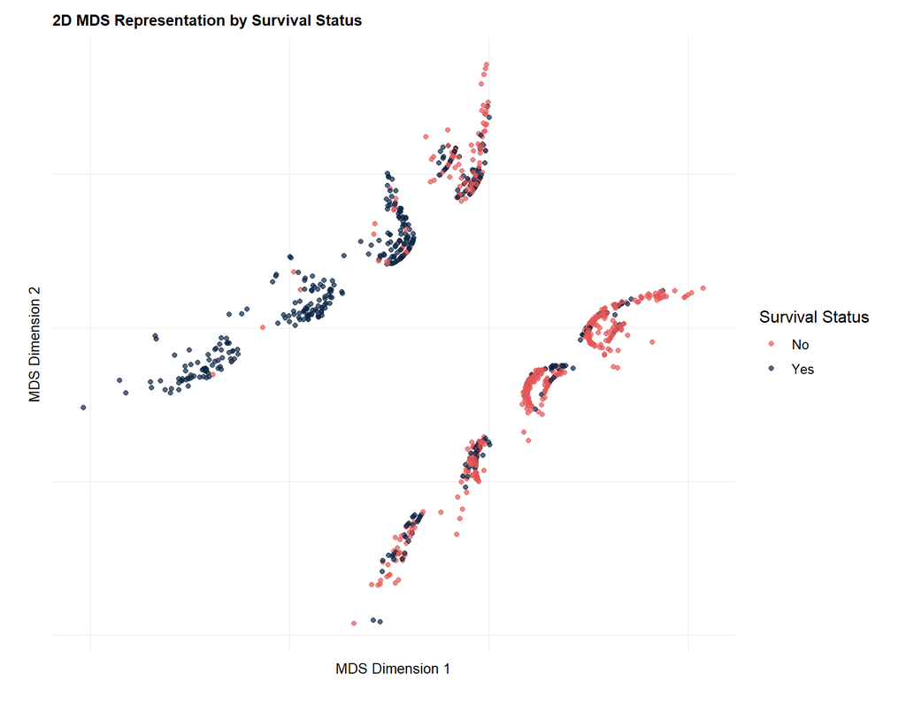

(a) Representation of MDS results in two-dimensional space.

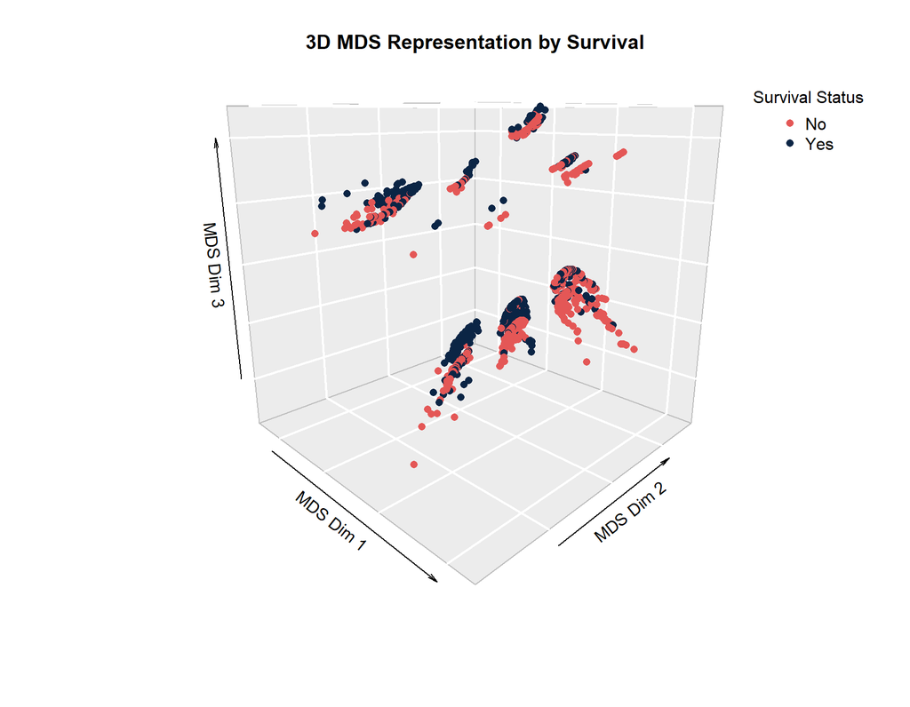

(b) Representation of MDS results in three-dimensional space.

Figure 13: Representation of MDS results in two- and three-dimensional spaces, coloured by passenger survival.

Among the survivors, three distinct clusters can be identified in which survivors predominate. These clusters also contain some observations corresponding to passengers who did not survive the disaster; however, these are isolated cases and may therefore be considered outliers.

Among the passengers who did not survive, approximately six clusters can be identified. However, these clusters are less distinct, as they contain a substantial number of observations corresponding to survivors.

These results suggest that certain passenger profiles were associated with a higher probability of survival. At the same time, the composition of the victim clusters suggests that non-survival was not as clearly associated with any specific passenger profile.

## 6.3 MDS Visualization by Passenger Characteristics

In this section, we further investigate the clusters identified through MDS. The observations are coloured according to selected variables to asses whether the identified clusters correspond to different categories or values of the passenger characteristics.

The results are presented in the interactive three-dimensional plot (Figure 14) and the two-dimensional plots (Figure 15).

[interactive chart not shown]

Figure 14: Interactive three-dimensional representation of MDS results, coloured by selected variables.

MDS captured the same key relationships associated with survival as those identified in the EDA (Section 4). The following description focuses on the two-dimensional plots.

- Sex is the main factor separating the clusters. The upper clusters consist of women, while the lower consist of men. This is a perfect separation, as no observations from the two categories overlap. The second most influential factor is passenger class, and consequently fare. Observations from different classes overlap to some extend, particulary those 2nd- and 3rd-classes. The cluster associated with the 1st-class is the largest (as indicated by the $95\%$ confidence ellipse size), which is likely related to the wide range of ticket fares within this class.

  It should also be emphasised that `survived` variable was not included in the MDS calculations and therefore did not influence the formation of clusters. In contrast, `age` and family size variables were included, although they do not appear to define the clusters as clearly. Nevertheless, these variables provide valuable additional context for interpreting the results.
- The MDS plots confirm several conclusions from the EDA. The centers of the $95\%$ confidence ellipses for non-survivors are aligned with the clusters of male passengers across all classes, with more survivors in the 1st-class. Most of female casualties are concentrated in the 3rd-class cluster.
- Age groups are relatively evenly distributed across passenger classes, with the exception of children. Most observations belonging to the child group are located towards the upper part of the plot, corresponding primarily to the 2nd- and 3rd-classes. This group also appears to have a relatively high fatality rate, as most of these observations are coloured red in the survival plot. This further supports the lower survival rate observed for 3rd-class children in Figure 8 (a).
- Family-size categories show a similar distribution, with some exceptions for medium and large families. The latter occur only within the 3rd-class clusters and are associated with non-survival. Medium-sized families also include some observations from the 1st- and 2nd-classes, where survival appears more likely than among passengers from the 3rd-class.

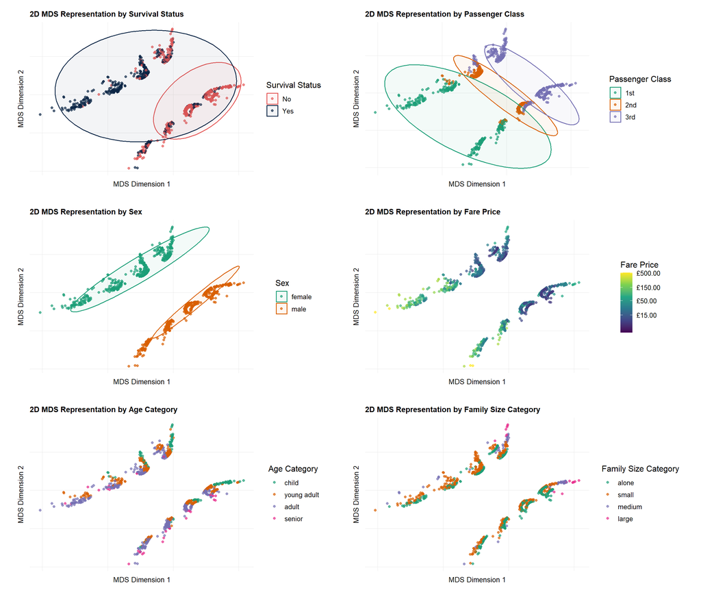

Figure 15: Two-dimensional representation of MDS results, coloured by selected variables.

## 6.4 MDS Summary

MDS revealed a clear structure in the dataset, with observations primarily separated along two dimensions. The strongest separation is observed by sex, with male and female passengers forming distinct, non-overlapping groups. Passenger class and fare provide a further, although less pronounced, gradient within these groups.

The structure revealed by MDS is consistent with the key findings from the EDA. Higher survival rates are concentrated among female and first-class passengers, whereas clusters with lower survival rates are predominantly composed of male passengers from the 2nd- and 3rd-classes. Large families are also associated with lower survival rates.

The observed structure also suggests that the relationships between passenger characteristics and survival may be non-linear. This makes tree-based classification methods, such as Random Forest, promising candidates for the predictive stage, as they can capture non-linear relationships and interactions between predictors without requiring them to be specified explicitly. Furthermore, the elongated, non-spherical shape of the clusters indicates that density-based or hierarchical clustering will perform significantly better than $K$-Means.

# 7 Modeling

Having explored the main patterns in the data, we now move on to the modelling stage. The dataset has been split into the training and test sets using a $80/20$ stratified (on `survived`) split, with a fixed seed of `12578891` to ensure that the results are repetitive.

Before any calculations, some variables were also removed. Most importantly, `lifeboat` has been excluded, because it determines `survival`. To reduce collinearity, the two variables `parents_children` and `siblings_spouses` were removed in favour of the single `family_size` feature. We also leave out categorical variables such as `is_child`, `age_group`, and `family_size_group`, as they largely duplicate information contained in the corresponding numerical variables. This also gives the models access to the original numerical information rather than its simplified qualitative versions.

The modeling section covers both unsupervised and supervised approaches:

- Unsupervised Learning: Clustering algorithms (AGNES and PAM) are used to assess whether natural passenger groupings align with survival patterns without using target labels.
- Supervised Learning: Classification algorithms are trained to predict individual survival outcomes based on passenger attributes.

To obtain more reliable and unbiased performance estimates, we use 10-fold cross-validation on ROC-AUC metrics. The test set remains entirely untouched during this phase and is reserved exclusively for the final evaluation of the champion model to verify its capability. This reduces the influence of any single random split of the training data and provides a more stable basis for comparing the different modelling approaches.

At the same time, we examine whether dimensionality reduction can provide useful additional information. PCA and Gower-based MDS are used to create two-dimensional representations of the training data. These new dimensions are then added to the original feature set, allowing us to compare the baseline models with versions enriched by PCA or MDS features.

To confirm that the $80\%$ training subset preserves the structural and geometric properties identified during EDA, we first inspect its projections.

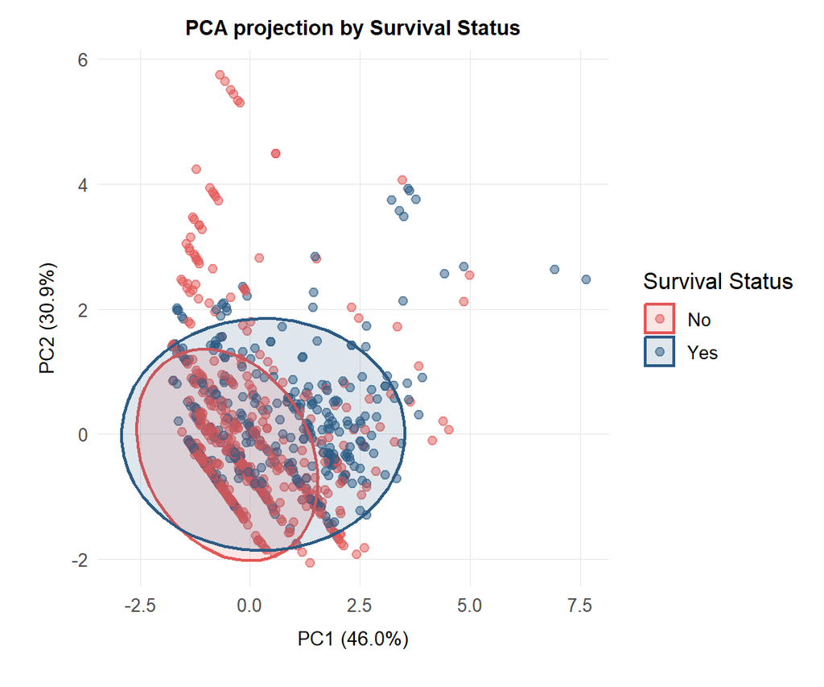

(a) PCA projection (quantitative variables and transformed `class`)

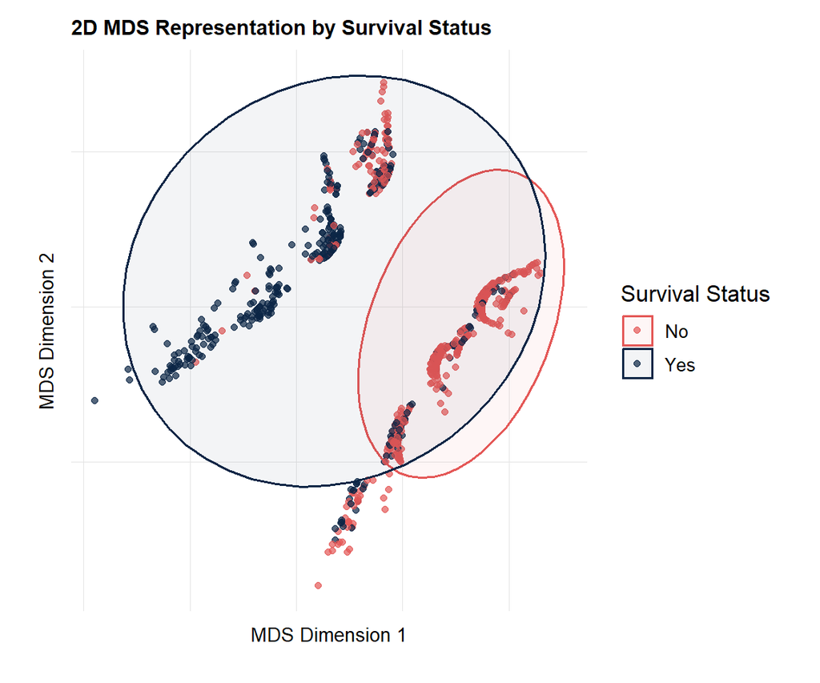

(b) 2D MDS projection (Gower distance for mixed-type data)

Figure 16: Unsupervised PCA projection and Gower distance-based MDS. Calculated using the training set (80% of data).

The visual analysis of Figure 16 confirms that the cluster structure remains stable and is broadly consistent the results obtained for the full dataset (see Figure 11 (a) and Figure 13 (a)). We continue to observe a separation between groups with higher and lower survival probabilities, driven primarily by the combined effects of sex and passenger class.

It is also worth noting a technical difference in the PCA results. On the training set, the first two principal components jointly explain approximately $77\%$ of the total variance, compared with around $68\%$ for the full dataset. This difference does not indicate a change in the data structure following the train-test split. Rather, it results from the feature selection conducted specifically for the modelling stage. For the full dataset calculations were done with both `parents_children` and `siblings_spouses`, while for the training set, only `family_size` was used. Thanks to that, PCA was able to capture a larger proportion of the remaining variance in its first two components.

## 7.1 Clustering

### 7.1.1 Partitioning Around Medoids (PAM)

The *Partitioning Around Medoids* (PAM) algorithm is a clustering method used to divide a dataset into a predefined number of distinct groups based on the distances between observations. Unlike methods like k-Means, which represent clusters using centroids, PAM uses medoids — actual observations from the dataset that serve as representative members of their respective cluster.

#### 7.1.1.1 Full feature space

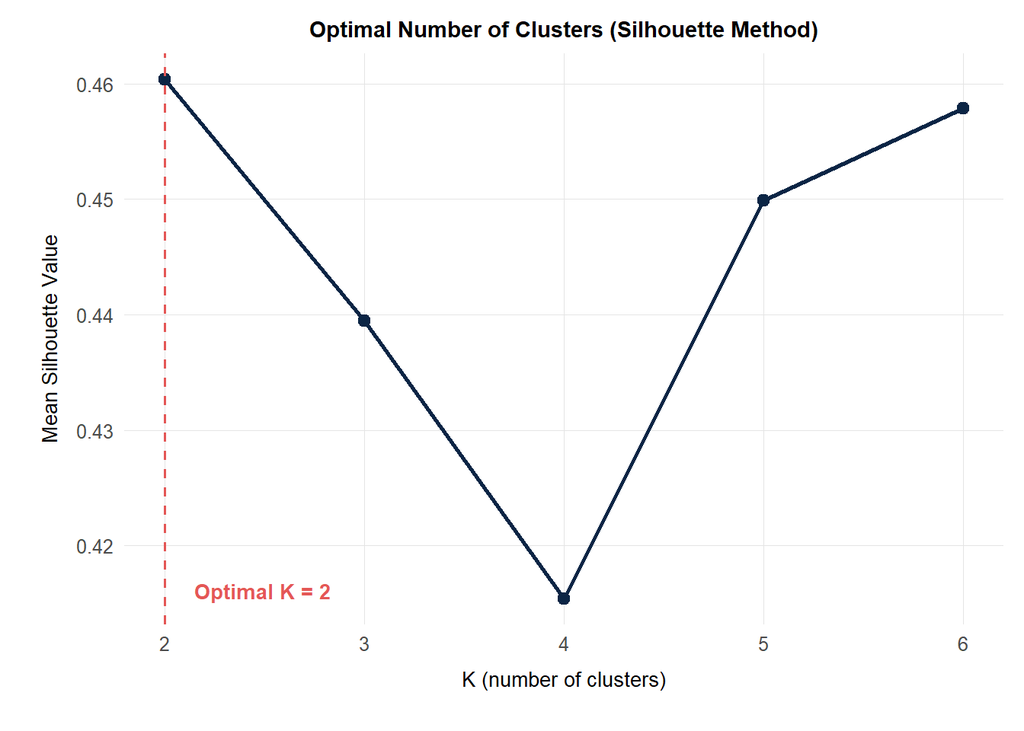

Figure 17: The Silhouette coefficient value for different K (number of clusters) values.

The first step was to determine the optimal number of clusters. This was done using the *Silhouette Method*, which measures how well each observation fits within its assigned cluster compared with the nearest neighbouring cluster. The silhouette coefficient ranges from -1 to 1, with higher values indicating better-separated and more cohesive clusters. As shown in in Figure 17, the highest mean silhouette coefficient was obtained for $K = 2$, making it the preferred choice, especially as this number of clusters correspond with two values of the `survived` variable. The second-highest values was obtained for $K=6$, although it was slightly lower.

| Cluster | Count | Rate of Survival | Dominant Sex | Dominant Class | Main Embarked | Median of Age | Median of Fare | Median of Family Size |
| --- | --- | --- | --- | --- | --- | --- | --- | --- |
| 1 | 300 | 13.7 | male | 3rd | S | 25 | 7.9 | 1 |
| 2 | 108 | 73.1 | female | 1st | C | 39 | 78.7 | 2 |
| 3 | 166 | 45.2 | female | 3rd | S | 22 | 12.2 | 2 |
| 4 | 113 | 25.7 | male | 3rd | C | 22 | 7.9 | 1 |
| 5 | 208 | 22.1 | male | 2nd | S | 34 | 26.0 | 1 |
| 6 | 141 | 90.8 | female | 2nd | S | 31 | 27.8 | 2 |

Table 5: Description of dominant type of a passenger in a cluster created by the PAM algorithm (K = 6).

Figure 18 shows the PAM clusters assignments projected onto the 2D MDS space. Comparing this result with the feature-coloured MDS plots in Figure 15 shows that, for $K = 2$, the main and only distinctions between the two clusters is sex.

Using $K = 6$ produces a more detailed segmentation of the passengers (Table 5). The resulting clusters appear to be differentiated mainly by sex and passenger class (and naturally fare). Notably, despite the target variable `survived` being excluded from the distance calculation, the resulting clusters nevertheless show clear differences in survival rates. This is particularly visible in clusters 1 and 6 — cluster 1 (predominantly 3rd-class males) has a low survival rate of $13\%$, while cluster 6 (predominantly 2nd-class females) reaches a rate of $90.8\%$. Thus, even though survival was not included in the clustering procedure, the resulting passenger profiles capture characteristics that are strongly associated with survival.

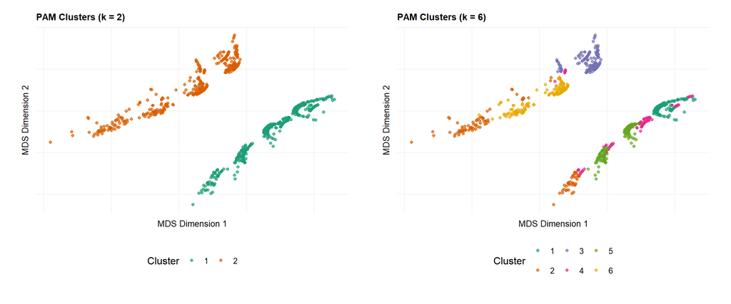

Figure 18: Visualisation of clusters created by the PAM algorithm. Plotted on the dimensions created by the MDS.

#### 7.1.1.2 Reduced feature space (PCA & MDS)

To asses how dimensionality reduction affects PAM clustering, the algorithm was applied directly to the two-dimensional spaces generated by MDS and PCA. The resulting partition are shown in Figure 19.

In the MDS projection, PAM produces the same sex-driven clustering pattern observed in the full Gower space. This is expected because MDS was constructed from the same pairwise Gower distances used by PAM, preserving the main structure of the original dissimilarity space.

Conversly, clustering in the PCA space produces a less distinct partition. Standard PCA relies on linear relationships among continuous variables, resulting in a denser observations cloud where PAM fails to establish clear class boundaries.

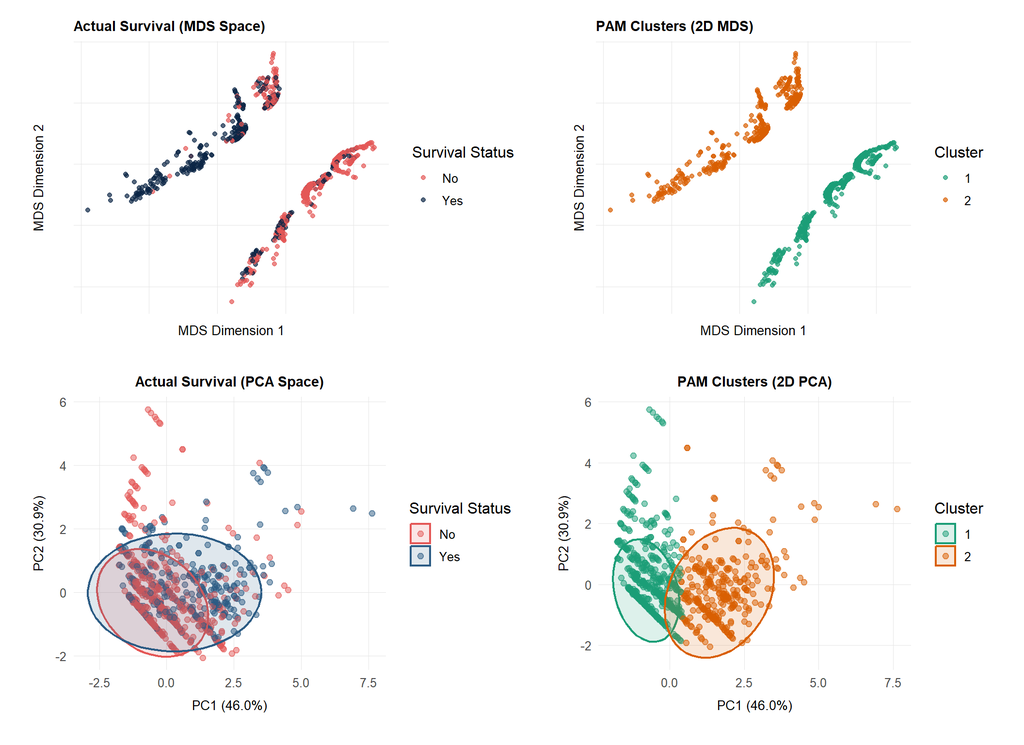

Figure 19: Comparison of actual survival status against PAM clustering outcomes across low-dimensional projections.

#### 7.1.1.3 PAM Performance

To compare the PAM configurations with the actual `surived` labels, four clustering setups were evaluated using the metrics in Table 6. Cluster agreement with the true labels is measured using the *Adjusted Rand Index* (ARI), where 0 indicates chance-level agreement and 1 indicates a perfect match. Traditional classification metrics (`Accuracy, Sensitivity, Specificity`) are calculated after assigning each cluster to either `Yes` or `No` survival value based on majority.

| Method | ARI | Accuracy | Sensitivity | Specificity |
| --- | --- | --- | --- | --- |
| PAM (Full Gower Matrix, k = 2) | 0.3038 | 0.7770 | 0.6910 | 0.8307 |
| PAM (Full Gower Matrix, k = 6) | 0.1232 | 0.7751 | 0.5201 | 0.9342 |
| PAM (2D PCA, k = 2) | 0.1015 | 0.6660 | 0.4497 | 0.8009 |
| PAM (2D MDS, k = 2) | 0.3038 | 0.7770 | 0.6910 | 0.8307 |

Table 6: Performance metrics for PAM clustering configurations benchmarked against actual survival labels.

The findings are:

- PAM in the 2D MDS space gives the same performance as PAM using the full Gower space ($ARI=0.3038$, $Accuracy=77.70\%$), suggesting that the two-dimensional MDS representation retains the main structure relevant to this clustering.
- PAM performs substantially worse in the PCA space ($ARI=0.1015$, $Accuracy=66.60\%$), with particularly low sensitivity ($44.97\%$). This indicates that the PCA representation is less suitable for this clustering task.
- The six-cluster solution has a lower $\text{ARI}$ ($0.1232$) but similar accuracy ($77.51\%$) and high specificity ($93.42\%$). The additional clusters therefore provide a more detailed partition, although this does not translate into stronger overall agreement with the survival labels.

Overall, within the PAM configurations considered here, the Gower-based representation performs better than PCA, while the 2D MDS representation retains the clustering structure of the full Gower space. These results provide a useful baseline for comparison with the AGNES results presented next.

### 7.1.2 Agglomerative Nesting (AGNES)

The *Agglomerative Nesting* (AGNES) algorithm is a hierarchical clustering method used to organize a dataset into a hierarchy of nested groups based on distances between observations. Unlike methods such as k-Means or PAM, which divide the data directly into a predefined number of clusters, AGNES starts by treating each observation as a separate cluster and then progressively merges the most similar clusters until a single one remains. The resulting hierarchy is represented as a dendrogram, which can be cut at a suitable level to obtain the desired number of clusters.

#### 7.1.2.1 Full feature space

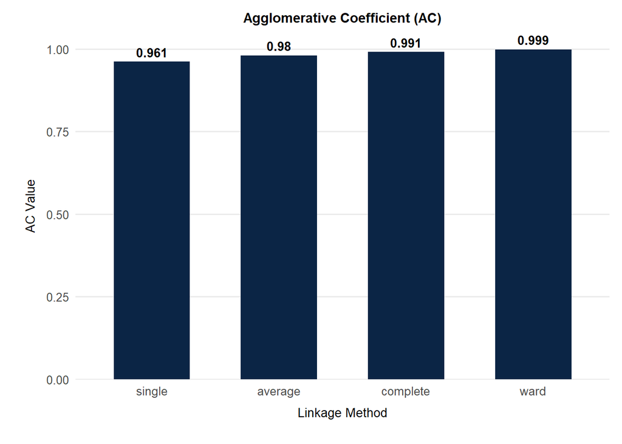

(a) Comparison of linkage methods by Agglomerative Coefficient value.

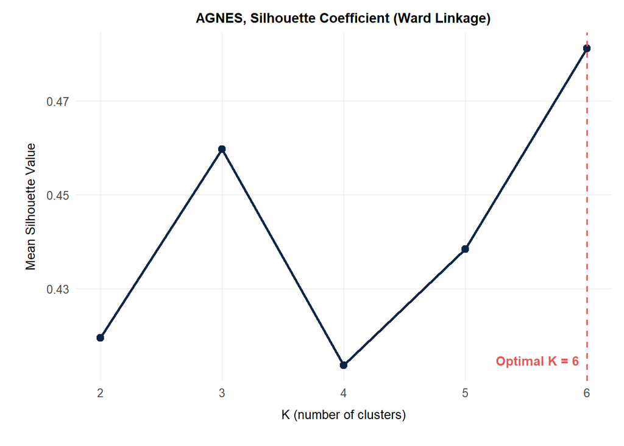

(b) The Silhouette coefficient value for different K (number of clusters) values.

Figure 20: AGNES parameter selection

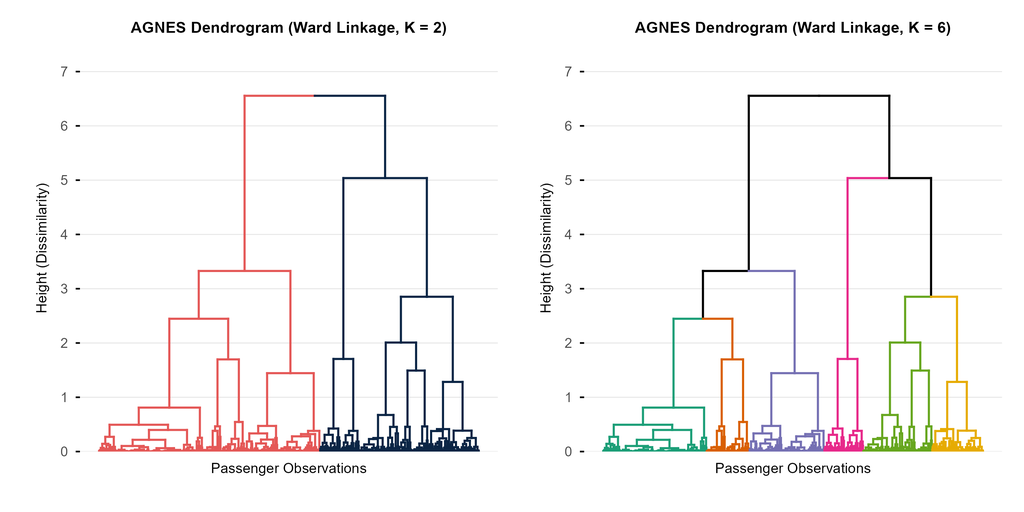

Figure 21 shows the hierarchical clustering structure produced by AGNES using Ward’s linkage method, with the trees coloured according to the resulting cluster assignments for $K = 2$ and $K = 6$. In a dendrogram, Height represents the dissimilarity between clusters at the point of their merge. The large increase in Height at the first split (Height $\approx 6.5$) indicates a substantial difference between the two resulting branches, suggesting a clear separation of the dataset into two major clusters. Those largely correspond to sex (see Figure 22).

| Cluster | Count | Rate of Survival | Dominant Sex | Dominant Class | Main Embarked | Median of Age | Median of Fare | Median of Family Size |
| --- | --- | --- | --- | --- | --- | --- | --- | --- |
| 1 | 282 | 13.1 | male | 3rd | S | 25 | 8.1 | 1 |
| 2 | 106 | 69.8 | female | 1st | C | 39 | 79.2 | 2 |
| 3 | 188 | 50.0 | female | 3rd | S | 22 | 12.3 | 2 |
| 4 | 117 | 17.9 | male | 3rd | C | 24 | 7.8 | 1 |
| 5 | 204 | 22.5 | male | 2nd | S | 34 | 26.0 | 1 |
| 6 | 139 | 90.6 | female | 2nd | S | 31 | 27.8 | 2 |

Table 7: Description of dominant type of a passenger in a cluster created by the AGNES algorithm (K = 6).

Figure 22 shows the AGNES clusters assignments projected onto the 2D MDS space, with observations coloured according to their cluster. For $K = 2$, sex remains the main dividing factor. However, in contrast to the PAM clustering (Figure 18), several observations from the male group have been assigned to the second cluster. As shown in Figure 15, these observations correspond to the male passengers from the 1st-class.

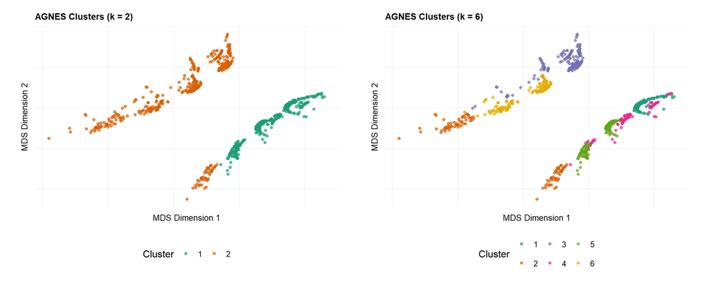

Figure 22: Visualisation of clusters created by the AGNES algorithm. Plotted on the dimensions created by the MDS.

#### 7.1.2.2 Reduced feature space (PCA & MDS)

As in the PAM analysis, we assess the effect of dimensionality reduction on the AGNES algorithm. The clustering was performed in the two-dimensional spaces generated by MDS and PCA, with the results shown in Figure 23.

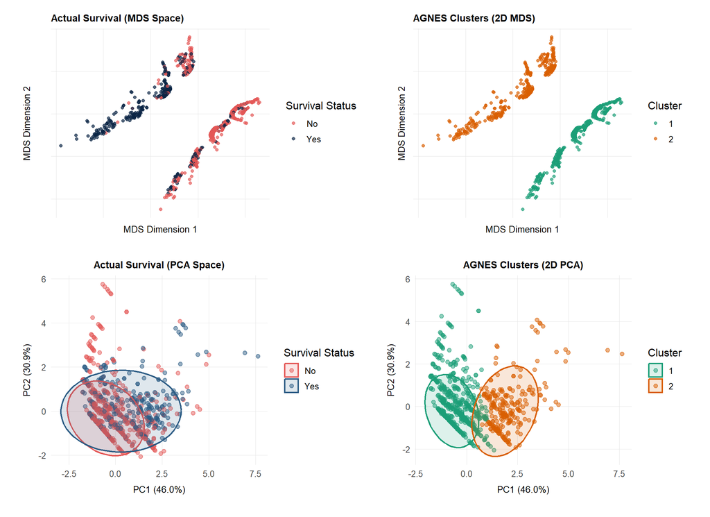

Figure 23: Comparison of actual survival status against AGNES clustering outcomes across low-dimensional projections.

In the MDS projection, AGNES produces clusters determined almost entirely by sex, in contrast to the more nuanced cluster assignments obtained in the full Gower space. Clustering in the PCA space yields results similar to those obtained with PAM (Figure 19), with most differences concentrated in the lower-central region of the observation cloud.

#### 7.1.2.3 AGNES Performance

Similarly to the PAM analysis, we compare four different AGNES configurations against the actual `surived` labels. The clustering results are evaluated using the *Adjusted Rand Index* (ARI) and traditional classification metrics, calculated after assigning each cluster to either `Yes` or `No` based on the majority survival outcome within the cluster. The results are presented in Table 8.

| Method | ARI | Accuracy | Sensitivity | Specificity |
| --- | --- | --- | --- | --- |
| AGNES (Full Gower Matrix, k = 2) | 0.2802 | 0.7654 | 0.7387 | 0.7821 |
| AGNES (Full Gower Matrix, k = 6) | 0.1163 | 0.7654 | 0.5025 | 0.9295 |
| AGNES (2D PCA, k = 2) | 0.1044 | 0.6718 | 0.3844 | 0.8511 |
| AGNES (2D MDS, k = 2) | 0.3038 | 0.7770 | 0.6910 | 0.8307 |

Table 8: Performance metrics for AGNES clustering configurations benchmarked against actual survival labels.

The key takeaways are:

- On the full Gower matrix ($K=2$), AGNES achieves an $\text{ARI}$ of $0.2802$ and an $\text{Accuracy}$ of $76.54\%$. Applying AGNES directly on the 2D MDS projection results in slightly higher scores ($\text{ARI} = 0.3038$, $\text{Accuracy} = 77.70\%$). This difference can be attributed to the different spatial representations — in the full Gower space, Ward linkage assigns some 1st-class male passengers to the same cluster as females, increasing $\text{Sensitivity}$ ($73.87\%$) while slightly reducing overall accuracy compared with the sex-driven separation in MDS space.
- The choice of dissimilarity representation appears to have a greater impact on the clustering results than the choice of clustering algorithm. Using Gower dissimilarity, either in its full matrix form or after 2D MDS projection, results in similar alignment with the survival labels, with approximately $78\%$ $\text{Accuracy}$ and an $ARI$ of around $0.30$. In contrast, clustering based on Euclidean distances in the PCA space achieves substantially lower alignment, at approximately $67\%$ $\text{Accuracy}$ and $\text{ARI} \approx 0.10$.
- Increasing the number of clusters to $K = 6$ maintains the same overall $\text{Accuracy}$ of $76.54\%$, while increasing $\text{Specificity}$ to $92.95\%$. The additional clusters provide a more detailed partition of the data, but this does not result in stronger overall agreement with the survival labels.

### 7.1.3 Clustering — Summary

- Both PAM and AGNES with Ward linkage produce very similar cluster assignments. Despite not using the survived variable, both methods consistently identify sex as the main factor driving the observed structure of the dataset.
- The choice of dissimilarity representation matters far more than the choice of clustering algorithm. Using Gower dissimilarity, either in its full matrix form or via 2D MDS, achieves baseline classification alignment of $\approx 78\%$ $\text{Accuracy}$ ($\text{ARI} \approx 0.30$). In contrast, Euclidean metrics applied to PCA components fail across both algorithms ($\approx 67\%$ $\text{Accuracy}$, $\text{ARI} \approx 0.10$).
- MDS proves to be an effective dimensionality reduction technique for clustering in this dataset. It preserves nearly all of the cluster-separating information contained in the full Gower distance matrix while substantially reducing dimensionality.

## 7.2 Supervised Learning

In this section, we move on to supervised learning methods. To examine how dimensionality reduction affects classification accuracy, each algorithm was evaluated using four different feature subsets:

- Full Dataset
- 2D MDS
- 2D PCA
- Full + 2D MDS — a new addition that combines preprocessed features with the MDS dimensions.

To ensure a random-proof evaluation and avoid data leakage, all models are evaluated using 10-fold Cross-Validation (CV). All feature processing steps, such as centering and scaling, were performed separately within each training fold.

### 7.2.1 Regression

The first supervised learning method used was *Logistic Regression*. Ordinary linear regression is not suitable for this task because the target variable is binary and linear regression can produce predictions outside the valid probability range of $[0, 1]$.

To address this, we use Logistic Regression, which models the log-odds of survival using the logit link function:

$$\ln\left(\frac{p}{1-p}\right) = \beta_0 + \beta_1 X_1 + \dots + \beta_k X_k$$

where $p = P(Y = \text{"Yes"} \mid X)$ represents the conditional probability of survival given the feature vector $X$.

In addition to providing a fast and interpretable baseline classifier, Logistic Regression allows the effects of individual features to be expressed through Odds Ratios ($e^\beta$). These provide a direct interpretation of how a one-unit increase in a feature affects the odds of survival, while keeping the other variables constant.

#### 7.2.1.1 Coefficients Interpretation

To evaluate the impact of individual features, the logistic regression coefficients ($\beta$) are converted into Odds Ratios ($OR = e^\beta$). Table 9 presents the estimated coefficients, Odds Ratio, confidence intervals, and statistical significance levels for each variable in the full model:

- Odds Ratio ($OR$) — shows how a given variable is associated with the odds of survival. Values above $1$ indicate higher odds, while values below $1$ indicate lower odds, with other variables held constant.
- $95\%$ Confidence Interval ($95\%$ CI) — provides a range of plausible values for the Odds Ratio. An interval that does not include $1.0$ indicates statistical significance at the $\alpha = 0.05$ level.
- $p$-Value — based on the Wald $z$-test, it tests null hypothesis that the variable has no effect on survival ($\beta = 0$, equivalent to $OR = 1.0$).
- Significance — significance levels are indicated by `***` ($p < 0.001$), `**` ($p < 0.01$), `*` ($p < 0.05$), and `ns` (not significant).

| Variable | Odds Ratio | 95% CI | p-Value | Significance |
| --- | --- | --- | --- | --- |
| class2nd | 0.615 | [0.49, 0.77] | 0.0000 | *** |
| class3rd | 0.298 | [0.22, 0.4] | 0.0000 | *** |
| sexmale | 0.277 | [0.23, 0.33] | 0.0000 | *** |
| fare | 0.973 | [0.77, 1.23] | 0.8189 | ns |
| embarkedQ | 0.881 | [0.73, 1.07] | 0.1946 | ns |
| embarkedS | 0.805 | [0.66, 0.97] | 0.0258 | * |
| age | 0.592 | [0.49, 0.72] | 0.0000 | *** |
| family_size | 0.746 | [0.61, 0.91] | 0.0031 | ** |

Table 9: Odds Ratios and Significance for Full Feature Logistic Regression Model

The fitted logistic regression model confirms the main survival patterns identified during the unsupervised analysis:

- Sex (`sexmale`) — being male is strongly associated with lower survival odds ($OR = 0.277, p < 0.001$). Holding other variables constant, male passengers had 72.3% lower survival odds than female passengers ($1 - 0.277 = 0.723$).
- Passenger Class (`class2nd`, `class3rd`) — survival odds were lower in both 2nd- and 3rd-class compared with 1st-class. For 3rd-class, the odds were $70.2\%$ lower ($OR = 0.298, p < 0.001$), while for 2nd-class they were $38.5\%$ lower ($OR = 0.615, p < 0.001$).
- Age (`age`) — negatively associated with survival ($OR = 0.592, p < 0.001$). A one-standard-deviation increase in age is associated with a $40.8\%$ decrease in survival odds.
- Family Size (`family_size`) — larger family sizes are associated with lower survival odds ($OR = 0.746, p = 0.0031$). A one-standard-deviation increase in family size corresponds to a $25.4\%$ decrease in survival odds.
- Fare & Embarkation (`fare`, `embarkedS`, `embarkedQ`) — passengers embarking at Southampton had lower survival odds than those embarking at Cherbourg ($OR = 0.805, p = 0.0258$). In contrast, fare was not statistically significant ($p = 0.8189$), suggesting that it provides little additional information about survival once passenger class is taken into account.

#### 7.2.1.2 Comparing Different Feature Spaces

To compare classification performance across the different feature sets, ROC curves were generated using the out-of-fold predictions from 10-fold CV. This allows us to compare how well Logistic Regression performs with each feature representation.

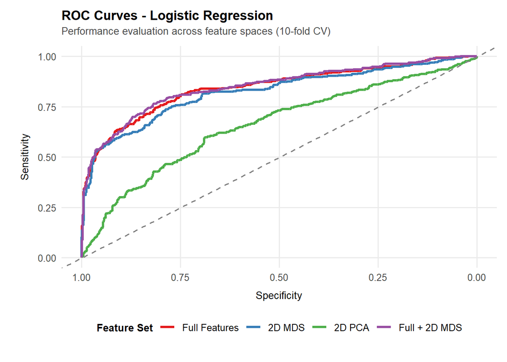

Figure 24: ROC Curves Comparison Across Feature Spaces for Logistic Regression

As shown in Figure 24, the ROC curves display very similar performance for the `Full Features`, `2D MDS`, and the hybrid `Full + 2D MDS`, with the curves almost completely overlapping. Conversely, `2D PCA` performs significantly worse, further confirming that linear PCA fails to capture critical relationships that MDS preserves.

**Note on Multicollinearity:** The hybrid `Full + 2D MDS` model shows substantial multicollinearity, as expected given that the MDS coordinates are derived from the same information as the original features. The VIF values are particularly high for the MDS coordinates ($VIF_x=86.87$, $VIF_y=137.42$), as well as for several of the original predictors. High VIF indicates that individual predictors contain overlapping information, which increases the uncertainty of their estimated regression coefficients and makes their individual effects difficult to interpret reliably. For this reason, odds-ratio interpretation is based on the `Full Features` model rather than the hybrid model. Importantly, high multicollinearity does not necessarily reduce the model’s predictive performance, so the classification metrics of the hybrid model can still be evaluated normally.